# Bank_Churn_Prediction

## **Introductory Steps**

### Importing Libraries

```python
# Importing all the required libraries
import pandas as pd
import numpy as np
from sklearn.model_selection import train_test_split
from sklearn.preprocessing import LabelEncoder, OneHotEncoder
from sklearn import model_selection
from sklearn.compose import ColumnTransformer
import matplotlib.pyplot as plt
import seaborn as sns
from sklearn.impute import SimpleImputer
import warnings
from sklearn.metrics import confusion_matrix
from sklearn.pipeline import Pipeline
from sklearn.model_selection import GridSearchCV
from sklearn.model_selection import RandomizedSearchCV
import tensorflow as tf
from tensorflow.keras.models import Sequential
from tensorflow.keras.layers import Dense
from tensorflow.keras.layers import Dense, Input, Dropout,BatchNormalization
from tensorflow.keras.wrappers.scikit_learn import KerasClassifier
import random
from tensorflow.keras import backend
from keras import callbacks
from keras.callbacks import ModelCheckpoint
from sklearn.preprocessing import LabelEncoder
from sklearn import preprocessing

from sklearn.metrics import roc_curve

from matplotlib import pyplot

from sklearn import metrics

from sklearn.metrics import confusion_matrix

random.seed(1)
np.random.seed(1)
tf.random.set_seed(1)
warnings.filterwarnings("ignore")
```

### Loading the Data

```python
# Data loading
bank_churn_df = pd.read_csv('Churn.csv')
```

```python
# Checking the number of rows and columns in the data
bank_churn_df.shape
```

```
(10000, 14)
```

- The dataset has 10000 rows and 14 columns

### Data Overview

```python
# Let's view the first 5 rows of the data
bank_churn_df.head()
```

|  | RowNumber | CustomerId | Surname | CreditScore | Geography | Gender | Age | Tenure | Balance | NumOfProducts | HasCrCard | IsActiveMember | EstimatedSalary | Exited |
| --- | --- | --- | --- | --- | --- | --- | --- | --- | --- | --- | --- | --- | --- | --- |
| 0 | 1 | 15634602 | Hargrave | 619 | France | Female | 42 | 2 | 0.00 | 1 | 1 | 1 | 101348.88 | 1 |
| 1 | 2 | 15647311 | Hill | 608 | Spain | Female | 41 | 1 | 83807.86 | 1 | 0 | 1 | 112542.58 | 0 |
| 2 | 3 | 15619304 | Onio | 502 | France | Female | 42 | 8 | 159660.80 | 3 | 1 | 0 | 113931.57 | 1 |
| 3 | 4 | 15701354 | Boni | 699 | France | Female | 39 | 1 | 0.00 | 2 | 0 | 0 | 93826.63 | 0 |
| 4 | 5 | 15737888 | Mitchell | 850 | Spain | Female | 43 | 2 | 125510.82 | 1 | 1 | 1 | 79084.10 | 0 |

```python
# view the bottom 5 rows of the data
bank_churn_df.tail()
```

|  | RowNumber | CustomerId | Surname | CreditScore | Geography | Gender | Age | Tenure | Balance | NumOfProducts | HasCrCard | IsActiveMember | EstimatedSalary | Exited |
| --- | --- | --- | --- | --- | --- | --- | --- | --- | --- | --- | --- | --- | --- | --- |
| 9995 | 9996 | 15606229 | Obijiaku | 771 | France | Male | 39 | 5 | 0.00 | 2 | 1 | 0 | 96270.64 | 0 |
| 9996 | 9997 | 15569892 | Johnstone | 516 | France | Male | 35 | 10 | 57369.61 | 1 | 1 | 1 | 101699.77 | 0 |
| 9997 | 9998 | 15584532 | Liu | 709 | France | Female | 36 | 7 | 0.00 | 1 | 0 | 1 | 42085.58 | 1 |
| 9998 | 9999 | 15682355 | Sabbatini | 772 | Germany | Male | 42 | 3 | 75075.31 | 2 | 1 | 0 | 92888.52 | 1 |
| 9999 | 10000 | 15628319 | Walker | 792 | France | Female | 28 | 4 | 130142.79 | 1 | 1 | 0 | 38190.78 | 0 |

```python
# Let's check the datatypes of the columns in the dataset
bank_churn_df.info()
```

```
<class 'pandas.core.frame.DataFrame'>
RangeIndex: 10000 entries, 0 to 9999
Data columns (total 14 columns):
 #   Column           Non-Null Count  Dtype
---  ------           --------------  -----
 0   RowNumber        10000 non-null  int64
 1   CustomerId       10000 non-null  int64
 2   Surname          10000 non-null  object
 3   CreditScore      10000 non-null  int64
 4   Geography        10000 non-null  object
 5   Gender           10000 non-null  object
 6   Age              10000 non-null  int64
 7   Tenure           10000 non-null  int64
 8   Balance          10000 non-null  float64
 9   NumOfProducts    10000 non-null  int64
 10  HasCrCard        10000 non-null  int64
 11  IsActiveMember   10000 non-null  int64
 12  EstimatedSalary  10000 non-null  float64
 13  Exited           10000 non-null  int64
dtypes: float64(2), int64(9), object(3)
memory usage: 1.1+ MB
```

```python
# Let's check for duplicate values in the data
bank_churn_df[:-1].duplicated().sum()
```

```
0
```

```python
# Let's check for missing values in the data
round(bank_churn_df.isnull().sum() / bank_churn_df.isnull().count() * 100, 2)
```

```
RowNumber          0.0
CustomerId         0.0
Surname            0.0
CreditScore        0.0
Geography          0.0
Gender             0.0
Age                0.0
Tenure             0.0
Balance            0.0
NumOfProducts      0.0
HasCrCard          0.0
IsActiveMember     0.0
EstimatedSalary    0.0
Exited             0.0
dtype: float64
```

- Dataset doesn't contain any missing value

```python
# Checking ratio of response variable
bank_churn_df["Exited"].value_counts(1)
```

```
0    0.7963
1    0.2037
Name: Exited, dtype: float64
```

```python
# Let's view the statistical summary of the numerical columns in the data
bank_churn_df.describe().T
```

|  | count | mean | std | min | 25% | 50% | 75% | max |
| --- | --- | --- | --- | --- | --- | --- | --- | --- |
| RowNumber | 10000.0 | 5.000500e+03 | 2886.895680 | 1.00 | 2500.75 | 5.000500e+03 | 7.500250e+03 | 10000.00 |
| CustomerId | 10000.0 | 1.569094e+07 | 71936.186123 | 15565701.00 | 15628528.25 | 1.569074e+07 | 1.575323e+07 | 15815690.00 |
| CreditScore | 10000.0 | 6.505288e+02 | 96.653299 | 350.00 | 584.00 | 6.520000e+02 | 7.180000e+02 | 850.00 |
| Age | 10000.0 | 3.892180e+01 | 10.487806 | 18.00 | 32.00 | 3.700000e+01 | 4.400000e+01 | 92.00 |
| Tenure | 10000.0 | 5.012800e+00 | 2.892174 | 0.00 | 3.00 | 5.000000e+00 | 7.000000e+00 | 10.00 |
| Balance | 10000.0 | 7.648589e+04 | 62397.405202 | 0.00 | 0.00 | 9.719854e+04 | 1.276442e+05 | 250898.09 |
| NumOfProducts | 10000.0 | 1.530200e+00 | 0.581654 | 1.00 | 1.00 | 1.000000e+00 | 2.000000e+00 | 4.00 |
| HasCrCard | 10000.0 | 7.055000e-01 | 0.455840 | 0.00 | 0.00 | 1.000000e+00 | 1.000000e+00 | 1.00 |
| IsActiveMember | 10000.0 | 5.151000e-01 | 0.499797 | 0.00 | 0.00 | 1.000000e+00 | 1.000000e+00 | 1.00 |
| EstimatedSalary | 10000.0 | 1.000902e+05 | 57510.492818 | 11.58 | 51002.11 | 1.001939e+05 | 1.493882e+05 | 199992.48 |
| Exited | 10000.0 | 2.037000e-01 | 0.402769 | 0.00 | 0.00 | 0.000000e+00 | 0.000000e+00 | 1.00 |

Name, Geography and Gender are Categorical features in the dataset and rest are numerical. We will check their descriptive statistics.

```python
# Let's check the number of unique values in each column
bank_churn_df.nunique()
```

```
RowNumber          10000
CustomerId         10000
Surname             2932
CreditScore          460
Geography              3
Gender                 2
Age                   70
Tenure                11
Balance             6382
NumOfProducts          4
HasCrCard              2
IsActiveMember         2
EstimatedSalary     9999
Exited                 2
dtype: int64
```

```python
for i in bank_churn_df.describe(include=["object"]).columns:
    print("Unique values in", i, "are :")
    print(bank_churn_df[i].value_counts())
    print("*" * 50)

for i in bank_churn_df[['Geography', 'Gender', 'Tenure', 'NumOfProducts', 'HasCrCard', 'IsActiveMember']]:
    print("Unique values in", i, "are :")
    print(bank_churn_df[i].value_counts())
    print("*" * 50)
```

```
Unique values in Surname are :
Smith       32
Scott       29
Martin      29
Walker      28
Brown       26
            ..
Dufresne     1
Jowett       1
Pendred      1
Postle       1
Davy         1
Name: Surname, Length: 2932, dtype: int64
Unique values in Geography are :
France     5014
Germany    2509
Spain      2477
Name: Geography, dtype: int64
Unique values in Gender are :
Male      5457
Female    4543
Name: Gender, dtype: int64
Unique values in Geography are :
France     5014
Germany    2509
Spain      2477
Name: Geography, dtype: int64
Unique values in Gender are :
Male      5457
Female    4543
Name: Gender, dtype: int64
Unique values in Tenure are :
2     1048
1     1035
7     1028
8     1025
5     1012
3     1009
4      989
9      984
6      967
10     490
0      413
Name: Tenure, dtype: int64
Unique values in NumOfProducts are :
1    5084
2    4590
3     266
4      60
Name: NumOfProducts, dtype: int64
Unique values in HasCrCard are :
1    7055
0    2945
Name: HasCrCard, dtype: int64
Unique values in IsActiveMember are :
1    5151
0    4849
Name: IsActiveMember, dtype: int64
```

- There are 2932 unique customer's last name present in the dataset with Smith, Scott, Martin, Walker being the most frequent ones.
- Customers geography is France, Germeny and Spain.
- ~55% of the employees in this dataset are males, and rest are females.
- Over 70% of the customers have credit card.
- Around 50% of the customers are active.

### Data Pre-processing

```python
# columns consists of uniques IDs and name of customers and hence will not add value to the modeling
bank_churn_df.drop(columns=['RowNumber', 'CustomerId', 'Surname'], inplace=True)
```

## **EDA**

### Univariate Analysis

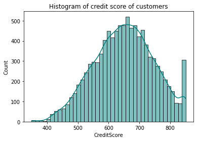

```python
ax = sns.histplot(data = bank_churn_df, x = "CreditScore",  kde=True, color="teal")
ax.set_title('Histogram of credit score of customers')
plt.show()
```

- The above plot shows the credit score distribution among customers
- Around 300 customers have max credit score

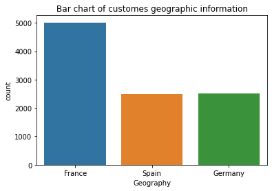

```python
ax = sns.countplot(data=bank_churn_df, x="Geography")
ax.set_title('Bar chart of customes geographic information')
plt.show()
```

- The barplot shows the frequency distribution of Geographic location of customers.
- Half of the customers in the sample are from France, and the remaing half are from Spain and Germany.

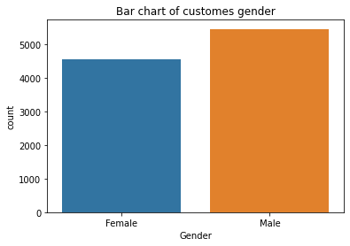

```python
ax = sns.countplot(data=bank_churn_df, x="Gender")
ax.set_title('Bar chart of customes gender')
plt.show()
```

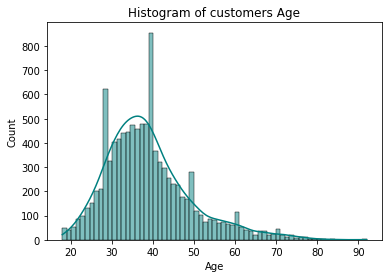

```python
ax = sns.histplot(data = bank_churn_df, x = "Age",  kde=True, color="teal")
ax.set_title('Histogram of customers Age')
plt.show()
```

- The histogram of customers age is right skewed with a long tail. It signifies that there are more younger customers in the sample.

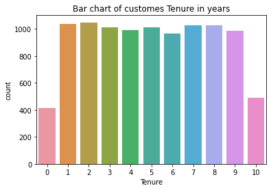

```python
ax = sns.countplot(data=bank_churn_df, x="Tenure")
ax.set_title('Bar chart of customes Tenure in years')
plt.show()
```

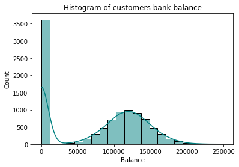

```python
ax = sns.histplot(data = bank_churn_df, x = "Balance",  kde=True, color="teal")
ax.set_title('Histogram of customers bank balance')
plt.show()
```

- The average balance gives a normal distribution curve, while 3500(35%) of the customers have zero bank balance in their account.

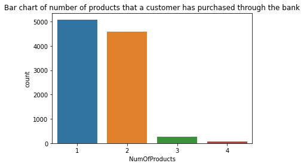

```python
ax = sns.countplot(data=bank_churn_df, x="NumOfProducts")
ax.set_title('Bar chart of number of products that a customer has purchased through the bank')
plt.show()
```

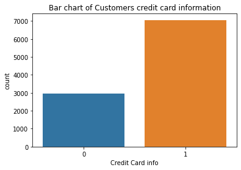

```python
ax = sns.countplot(data=bank_churn_df, x="HasCrCard")
ax.set_title('Bar chart of Customers credit card information')
ax.set_xlabel('Credit Card info')
plt.show()
```

- Around 70% of the customers have credit card

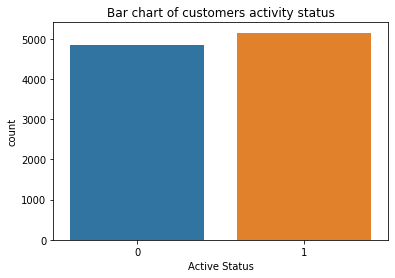

```python
ax = sns.countplot(data=bank_churn_df, x="IsActiveMember")
ax.set_title('Bar chart of customers activity status')
ax.set_xlabel('Active Status')
plt.show()
```

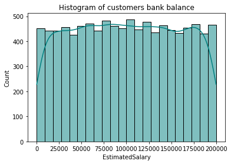

```python
ax = sns.histplot(data = bank_churn_df, x = "EstimatedSalary",  kde=True, color="teal")
ax.set_title('Histogram of customers bank balance')
plt.show()
```

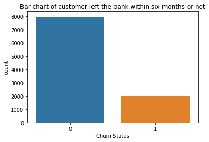

```python
ax = sns.countplot(data=bank_churn_df, x="Exited")
ax.set_title('Bar chart of customer left the bank within six months or not')
ax.set_xlabel('Churn Status')
plt.show()
```

- The sample dataset contains 20% churn (exit within 6 month) customers information

### Bivariate Analysis

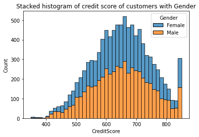

```python
# Visualization of credit score of customers with Gender
ax = sns.histplot(x = 'CreditScore', hue='Gender', data=bank_churn_df, multiple="stack")
ax.set_title('Stacked histogram of credit score of customers with Gender')
plt.show()
```

- Credit scores are distributed normally among males and females.

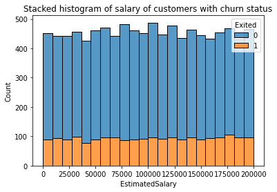

```python
# Visualization of salary of customers with churn status
ax = sns.histplot(x = 'EstimatedSalary', hue='Exited', data=bank_churn_df, multiple="stack")
ax.set_title('Stacked histogram of salary of customers with churn status')
plt.show()
```

- Extimated salary of customers shows uniform distribution among all customers, and also within churn status.

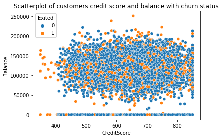

```python
# Plotting scatterplot
ax = sns.scatterplot(data=bank_churn_df, x="CreditScore", y="Balance", hue="Exited")
ax.set_title('Scatterplot of customers credit score and balance with churn status')
plt.show()
```

### Encoding Categorical data

```python
## Separating Independent and Dependent Columns
X = bank_churn_df.drop(['Exited'],axis=1)
Y = bank_churn_df[['Exited']]
```

```python
# Splitting the dataset into the Training and Testing set.
X_train, X_test, y_train, y_test = train_test_split(X,Y, test_size = 0.2, random_state = 42,stratify = Y)
```

```python
# Lable encoding of the data
labelencoder_Geo = LabelEncoder()
X_train['Geography']= labelencoder_Geo.fit_transform(X_train['Geography'])
X_test['Geography']= labelencoder_Geo.transform(X_test['Geography'])

labelencoder_Gender = LabelEncoder()
X_train['Gender']= labelencoder_Gender.fit_transform(X_train['Gender'])
X_test['Gender']= labelencoder_Gender.transform(X_test['Gender'])
```

```python
# Printing top 5 rows of the sample dataset
X_train.head()
```

|  | CreditScore | Geography | Gender | Age | Tenure | Balance | NumOfProducts | HasCrCard | IsActiveMember | EstimatedSalary |
| --- | --- | --- | --- | --- | --- | --- | --- | --- | --- | --- |
| 2151 | 753 | 0 | 1 | 57 | 7 | 0.00 | 1 | 1 | 0 | 159475.08 |
| 8392 | 739 | 1 | 1 | 32 | 3 | 102128.27 | 1 | 1 | 0 | 63981.37 |
| 5006 | 755 | 1 | 0 | 37 | 0 | 113865.23 | 2 | 1 | 1 | 117396.25 |
| 4117 | 561 | 0 | 1 | 37 | 5 | 0.00 | 2 | 1 | 0 | 83093.25 |
| 7182 | 692 | 1 | 1 | 49 | 6 | 110540.43 | 2 | 0 | 1 | 107472.99 |

```python
y_train.head()
```

|  | Exited |
| --- | --- |
| 2151 | 1 |
| 8392 | 1 |
| 5006 | 0 |
| 4117 | 0 |
| 7182 | 0 |

```python
# Using standard scale to standardize the training data
std_scaler = preprocessing.StandardScaler()
X_train = std_scaler.fit_transform(X_train)
X_test = std_scaler.transform(X_test)
```

```python
# Printing top 5 rows of the training dataset after transformation
X_train[0:5,:]
```

```
array([[ 1.058568  , -0.90593285,  0.90750738,  1.71508648,  0.68472287,
        -1.22605881, -0.91025649,  0.64104192, -1.030206  ,  1.04208392],
       [ 0.91362605,  0.30016846,  0.90750738, -0.65993547, -0.6962018 ,
         0.41328769, -0.91025649,  0.64104192, -1.030206  , -0.62355635],
       [ 1.07927399,  0.30016846, -1.10191942, -0.18493108, -1.73189531,
         0.60168748,  0.80883036,  0.64104192,  0.97067965,  0.30812779],
       [-0.92920731, -0.90593285,  0.90750738, -0.18493108, -0.00573947,
        -1.22605881,  0.80883036,  0.64104192, -1.030206  , -0.29019914],
       [ 0.42703522,  0.30016846,  0.90750738,  0.95507945,  0.3394917 ,
         0.54831832,  0.80883036, -1.55996038,  0.97067965,  0.13504224]])
```

```python
###Checking the shape of train and test sets
print(X_train.shape)
print(X_test.shape)
print(y_train.shape)
print(y_test.shape)
```

```
(8000, 10)
(2000, 10)
(8000, 1)
(2000, 1)
```

## **Model Building**

The model building using neural networks is an iterative process. We will start building our model with a base model. Afterwards, I'll add more layers to the model with minor changes in the parameters until the model becomes robust and free of overfitting/underfitting.

### Model 1

```python
backend.clear_session()
#Fixing the seed for random number generators so that we can ensure we receive the same output everytime
np.random.seed(42)
import random
random.seed(42)
tf.random.set_seed(42)
```

```python
# Initializing the ANN
model = Sequential()

# Since the input has 10 parameters
model.add(Dense(activation = 'relu', input_dim = 10, units=64))

#Add 1st hidden layer
model.add(Dense(32, activation='relu'))

# Adding the output layer
# We use the sigmoid because we want probability outcomes
model.add(Dense(1, activation = 'sigmoid'))
```

```python
# Create optimizer with default learning rate and metric as accuracy with loss of cross entropy
# Compile the model
model.compile(optimizer='SGD', loss='binary_crossentropy', metrics=['accuracy'])
```

```python
model.summary()
```

```
Model: "sequential"
_________________________________________________________________
Layer (type)                 Output Shape              Param #
=================================================================
dense (Dense)                (None, 64)                704
_________________________________________________________________
dense_1 (Dense)              (None, 32)                2080
_________________________________________________________________
dense_2 (Dense)              (None, 1)                 33
=================================================================
Total params: 2,817
Trainable params: 2,817
Non-trainable params: 0
_________________________________________________________________
```

```python
# Modelling fitting with 32 batch size for 50 epochs
history=model.fit(X_train, y_train,
                  validation_split=0.2,
                  epochs=50,
                  batch_size=32,
                  verbose=1)
```

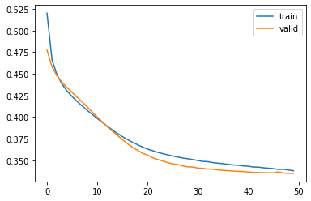

```python
# Capturing learning history per epoch
hist  = pd.DataFrame(history.history)
hist['epoch'] = history.epoch

# Plotting accuracy at different epochs
plt.plot(hist['loss'])
plt.plot(hist['val_loss'])
plt.legend(("train" , "valid") , loc =0)

#Printing results
results = model.evaluate(X_test, y_test)
```

```
Best Threshold=0.182024, G-Mean=0.767
```

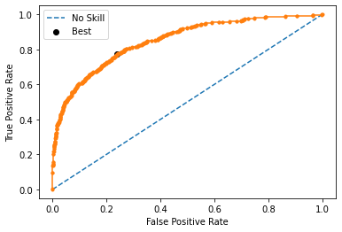

```python
# predict probabilities
yhat1 = model.predict(X_test)

# keep probabilities for the positive outcome only
yhat1 = yhat1[:, 0]

# calculate roc curves
fpr, tpr, thresholds1 = roc_curve(y_test, yhat1)

# calculate the g-mean for each threshold
gmeans1 = np.sqrt(tpr * (1-fpr))

# locate the index of the largest g-mean
ix = np.argmax(gmeans1)
print('Best Threshold=%f, G-Mean=%.3f' % (thresholds1[ix], gmeans1[ix]))

# plot the roc curve for the model
pyplot.plot([0,1], [0,1], linestyle='--', label='No Skill')
pyplot.plot(fpr, tpr, marker='.')
pyplot.scatter(fpr[ix], tpr[ix], marker='o', color='black', label='Best')

# axis labels
pyplot.xlabel('False Positive Rate')
pyplot.ylabel('True Positive Rate')
pyplot.legend()

# show the plot
pyplot.show()
```

```python
# Function to make confustion matrix
def make_confusion_matrix(cf,
                          group_names=None,
                          categories='auto',
                          count=True,
                          percent=True,
                          cbar=True,
                          xyticks=True,
                          xyplotlabels=True,
                          sum_stats=True,
                          figsize=None,
                          cmap='Blues',
                          title=None):
    '''
    This function will make a pretty plot of an sklearn Confusion Matrix cm using a Seaborn heatmap visualization.
    Arguments
    '''


    # CODE TO GENERATE TEXT INSIDE EACH SQUARE
    blanks = ['' for i in range(cf.size)]

    if group_names and len(group_names)==cf.size:
        group_labels = ["{}\n".format(value) for value in group_names]
    else:
        group_labels = blanks

    if count:
        group_counts = ["{0:0.0f}\n".format(value) for value in cf.flatten()]
    else:
        group_counts = blanks

    if percent:
        group_percentages = ["{0:.2%}".format(value) for value in cf.flatten()/np.sum(cf)]
    else:
        group_percentages = blanks

    box_labels = [f"{v1}{v2}{v3}".strip() for v1, v2, v3 in zip(group_labels,group_counts,group_percentages)]
    box_labels = np.asarray(box_labels).reshape(cf.shape[0],cf.shape[1])


    # CODE TO GENERATE SUMMARY STATISTICS & TEXT FOR SUMMARY STATS
    if sum_stats:
        #Accuracy is sum of diagonal divided by total observations
        accuracy  = np.trace(cf) / float(np.sum(cf))



    # SET FIGURE PARAMETERS ACCORDING TO OTHER ARGUMENTS
    if figsize==None:
        #Get default figure size if not set
        figsize = plt.rcParams.get('figure.figsize')

    if xyticks==False:
        #Do not show categories if xyticks is False
        categories=False


    # MAKE THE HEATMAP VISUALIZATION
    plt.figure(figsize=figsize)
    sns.heatmap(cf,annot=box_labels,fmt="",cmap=cmap,cbar=cbar,xticklabels=categories,yticklabels=categories)


    if title:
        plt.title(title)
```

```python
#Predicting the results using best as a threshold
y_pred_e1=model.predict(X_test)
y_pred_e1 = (y_pred_e1 > thresholds1[ix])
y_pred_e1
```

```
array([[False],
       [False],
       [False],
       ...,
       [ True],
       [False],
       [False]])
```

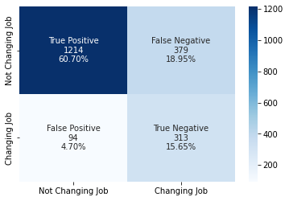

```python
#Calculating the confusion matrix
cm1=confusion_matrix(y_test, y_pred_e1)
labels = ['True Positive','False Negative','False Positive','True Negative']
categories = [ 'Not Changing Job','Changing Job']
make_confusion_matrix(cm1,
                      group_names=labels,
                      categories=categories,
                      cmap='Blues')
```

```python
#Accuracy as per the classification report
cr=metrics.classification_report(y_test,y_pred_e1)
print(cr)
```

```
              precision    recall  f1-score   support

           0       0.93      0.76      0.84      1593
           1       0.45      0.77      0.57       407

    accuracy                           0.76      2000
   macro avg       0.69      0.77      0.70      2000
weighted avg       0.83      0.76      0.78      2000
```

- The base model gives 76% accuracy on the test data with 84% and 57% f1-score of class 0 and 1 respectively.

We can improve this model by avoiding overfitting and adding more dense layer

### Model 2

Building complex model with more dense layer compared to model1.

```python
model2 = Sequential()
model2.add(Dense(256,activation='relu',input_dim = X_train.shape[1]))
model2.add(Dropout(0.2))
model2.add(Dense(128,activation='relu'))
model2.add(Dropout(0.2))
model2.add(Dense(64,activation='relu'))
model2.add(Dropout(0.2))
model2.add(Dense(32,activation='relu'))
model2.add(Dense(1, activation = 'sigmoid'))
```

```python
optimizer = tf.keras.optimizers.SGD(0.005)
model2.compile(loss='binary_crossentropy',optimizer=optimizer,metrics=['accuracy'])
```

```python
model2.summary()
```

```
Model: "sequential_1"
_________________________________________________________________
Layer (type)                 Output Shape              Param #
=================================================================
dense_3 (Dense)              (None, 256)               2816
_________________________________________________________________
dropout (Dropout)            (None, 256)               0
_________________________________________________________________
dense_4 (Dense)              (None, 128)               32896
_________________________________________________________________
dropout_1 (Dropout)          (None, 128)               0
_________________________________________________________________
dense_5 (Dense)              (None, 64)                8256
_________________________________________________________________
dropout_2 (Dropout)          (None, 64)                0
_________________________________________________________________
dense_6 (Dense)              (None, 32)                2080
_________________________________________________________________
dense_7 (Dense)              (None, 1)                 33
=================================================================
Total params: 46,081
Trainable params: 46,081
Non-trainable params: 0
_________________________________________________________________
```

```python
es_cb = callbacks.EarlyStopping(monitor='val_loss', min_delta=0.001, patience=5)
history=model2.fit(X_train, y_train,
                  validation_split=0.2,
                  epochs=100,
                  batch_size=32,
                  callbacks=es_cb,
                  verbose=1)
```

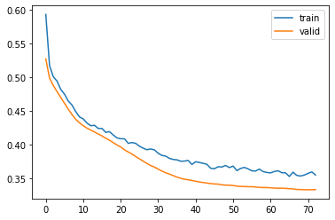

```python
# Capturing learning history per epoch
hist  = pd.DataFrame(history.history)
hist['epoch'] = history.epoch

# Plotting accuracy at different epochs
plt.plot(hist['loss'])
plt.plot(hist['val_loss'])
plt.legend(("train" , "valid") , loc =0)

#Printing results
results = model2.evaluate(X_test, y_test)
```

From the above plot, we observe that both the curves train and validation are smooth.

```
Best Threshold=0.210246, G-Mean=0.777
```

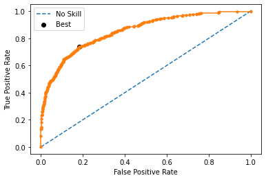

```python
# predict probabilities
yhat2 = model2.predict(X_test)

# keep probabilities for the positive outcome only
yhat2 = yhat2[:, 0]

# calculate roc curves
fpr, tpr, thresholds2 = roc_curve(y_test, yhat2)

# calculate the g-mean for each threshold
gmeans2 = np.sqrt(tpr * (1-fpr))

# locate the index of the largest g-mean
ix = np.argmax(gmeans2)
print('Best Threshold=%f, G-Mean=%.3f' % (thresholds2[ix], gmeans2[ix]))

# plot the roc curve for the model
pyplot.plot([0,1], [0,1], linestyle='--', label='No Skill')
pyplot.plot(fpr, tpr, marker='.')
pyplot.scatter(fpr[ix], tpr[ix], marker='o', color='black', label='Best')

# axis labels
pyplot.xlabel('False Positive Rate')
pyplot.ylabel('True Positive Rate')
pyplot.legend()

# show the plot
pyplot.show()
```

```python
#Predicting the results using best as a threshold
y_pred_e2=model2.predict(X_test)
y_pred_e2 = (y_pred_e2 > thresholds2[ix])
y_pred_e2
```

```
array([[False],
       [False],
       [False],
       ...,
       [ True],
       [False],
       [False]])
```

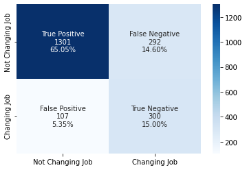

```python
#Calculating the confusion matrix
cm1=confusion_matrix(y_test, y_pred_e2)
labels = ['True Positive','False Negative','False Positive','True Negative']
categories = [ 'Not Changing Job','Changing Job']
make_confusion_matrix(cm1,
                      group_names=labels,
                      categories=categories,
                      cmap='Blues')
```

```python
#Accuracy as per the classification report
cr=metrics.classification_report(y_test,y_pred_e2)
print(cr)
```

```
              precision    recall  f1-score   support

           0       0.92      0.82      0.87      1593
           1       0.51      0.74      0.60       407

    accuracy                           0.80      2000
   macro avg       0.72      0.78      0.73      2000
weighted avg       0.84      0.80      0.81      2000
```

The Dropout technique helped the model reduce the loss function of both train and validation. The F1 score also seems to be fine, with a huge decrease in the False Negatives with a small increase in False Positives.

The final model gives an accuracy score of 80% with f1-score of 87% and 60% of class 0 and 1 respectively. Which is significantly better than the previous model.

### Score of Improvement

- The model can be improved by trying different-2 archeticture of Dense layer.
- The dataset is too small for neural networks. Adding more data into the model or by trying oversampling techniques can help the model improve.
- The model can be better tune with the use of RandomsearchCV, GridsearchCV or KerasTuner to find a better learning rate, drop out score and loss metrics.

### Business Recommendations

- The bank can deploy the final model from this exercise to identify with a reasonable degree of accuracy whether a customer will leave and join another service provider within next 6 month, and this process seems to be easier and more time-efficient than other methods.